# Taller Introducción a R

Centro Académico de Cómputos · Facultad de Ciencias Sociales · UPR-RP

Autor/a

Afiliación

Rashid C.J. Marcano Rivera, Ph.D., M.S., M.A.

Departamento de Sociología y Antropología

Fecha de publicación

17 de abril de 2026

# Bienvenida

Este taller introduce el lenguaje **R** y el entorno **RStudio** para personas en Ciencias Sociales y Humanidades. La sesión combina dos hilos sustantivos:

1. **Hilo cuantitativo (política comparada)**: encuesta del referéndum chileno de 1988 (`carData::Chile`) — exploración, visualización y un modelo lineal sobre el apoyo al régimen.
2. **Hilo cualitativo (humanidades digitales)**: comparación de frecuencias léxicas entre dos novelas del canon hispano separadas por casi tres siglos: *Don Quijote de la Mancha* (Cervantes, 1605) y *Fortunata y Jacinta* (Galdós, 1887).

## Base y referencias del taller

La introducción a R y RStudio (instalación, paneles, calculadora, asignación, vectores, funciones, tipos de datos y conceptos básicos de programación) toma como base los capítulos 1–3 del libro **Rafael A. Irizarry — *Introducción a la ciencia de datos*** (Harvard, edición en español, gratuito):

- Capítulo 1: [Comenzando con R y RStudio](https://rafalab.dfci.harvard.edu/dslibro/getting-started.html)
- Capítulo 2: [Conceptos básicos de R](https://rafalab.dfci.harvard.edu/dslibro/r-basics.html)
- Capítulo 3: [Conceptos básicos de programación](https://rafalab.dfci.harvard.edu/dslibro/conceptos-básicos-de-programación.html)
- Libro completo: https://rafalab.dfci.harvard.edu/dslibro/

Los casos sustantivos (Chile 1988, comparación Cervantes/Galdós) y la adaptación pedagógica para audiencia CSyH son contribuciones del autor de este taller, basadas en sesiones previas dictadas en la UPR-RP.

**Detalles logísticos**

- **Fecha**: viernes 17 de abril de 2026, 10:00 a.m. – 12:00 p.m.
- **Salón**: REB-120
- **Recurso**: Dr. Rashid C.J. Marcano Rivera (Sociología, FCS-UPRRP)
- **Coordinación**: CACCS — `caccs.rp@upr.edu` · Ext. 87751

## Cómo usar este documento

Hay dos tipos de recuadros con orientación según experiencia previa:

**AdvertenciaSi nunca han trabajado con código**

Recuadros amarillos con contexto adicional para quienes llegan sin experiencia en programación.

**TipSi han usado SPSS o Stata**

Recuadros verdes que conectan lo que ya saben con su equivalente en R.

# 1 Por qué R en Ciencias Sociales y Humanidades

R es un lenguaje creado por estadísticos como ambiente interactivo para análisis de datos. Es **gratuito, de código abierto y modular**: la comunidad ha desarrollado paquetes que cubren disciplinas desde la sociología cuantitativa y la economía política hasta la lingüística computacional, la historia digital y el análisis de redes. Usos relevantes para la facultad incluyen:

- **Análisis cuantitativo de encuestas, censos y registros** — limpieza, transformación, modelos.
- **Análisis de textos** — corpus literarios, prensa, transcripciones, discursos políticos.
- **Visualización de datos culturales y temporales** — líneas de tiempo, mapas, comparaciones entre regiones o periodos.
- **Reproducibilidad** — cada paso del análisis queda documentado en un *script* que ustedes (o colegas) pueden volver a correr.
- **Acceso a datos abiertos** — desde el Banco Mundial hasta el Proyecto Gutenberg en español.

**Antes de empezar — tres hábitos útiles** (siguiendo a Irizarry, cap. 2)

1. **Saber pedir ayuda**: `help(función)` o `?función` muestra documentación interna; `args(función)` lista solo los argumentos; `??término` busca por palabra clave; [StackOverflow con la etiqueta R](https://stackoverflow.com/questions/tagged/r) cubre casi cualquier duda.
2. **Leer los mensajes de error**: están diseñados para transmitir información. Con la práctica se vuelven informativos.
3. **Preferir `<-` sobre `=` para asignar**: ambos funcionan, pero `<-` deja claro visualmente que se trata de una asignación y reduce confusión con argumentos de funciones que usan `=`.

# 2 RStudio y R como calculadora

## 2.1 Los cuatro paneles de RStudio

RStudio es la interfaz que usaremos sobre R. Organiza el trabajo en cuatro paneles (Irizarry, cap. 1):

- **Source** (Fuente): editor donde escribimos *scripts* y documentos Quarto.
- **Console** (Consola): donde R ejecuta comandos y muestra resultados.
- **Environment** (Ambiente): los objetos que vamos creando.
- **Output** (Salida): archivos, gráficos, paquetes, ayuda.

Atajos de teclado para ejecutar código desde el editor:

| Acción | Mac | Windows / Linux |
| --- | --- | --- |
| Ejecutar la línea (o selección) actual | **Cmd + Return** | **Ctrl + Enter** |
| Ejecutar el *script* completo | **Cmd + Shift + Return** | **Ctrl + Shift + Enter** |

**ImportanteRecomendación de Irizarry: no restaurar `.RData` automáticamente**

Por defecto, RStudio guarda los objetos del ambiente al cerrar y los restaura al abrir. Esto **rompe la reproducibilidad**: el *script* depende de cosas que no están escritas en él. Vayan a **Tools → Global Options → General** y:

- **Desmarquen** “Restore .RData into workspace at startup”
- En “Save workspace to .RData on exit”, elijan **Never**

Así cada sesión empieza limpia y todo lo que necesitan está en el *script*.

## 2.2 R como calculadora

```r
1 + 2
```

```
[1] 3
```

```r
13 / 2
```

```
[1] 6.5
```

```r
2 ^ 6
```

```
[1] 64
```

```r
sqrt(81)
```

```
[1] 9
```

## 2.3 Asignar valores a objetos

La asignación se hace con `<-` (preferido) o `=`. Léanlo como “este nombre **recibe** este valor”.

```r
pais <- "Chile"
pais
```

```
[1] "Chile"
```

```r
año_referéndum <- 1988
años_desde <- 2026 - año_referéndum
años_desde
```

```
[1] 38
```

```r
# Valores lógicos (TRUE/FALSE)
es_caso_estudio <- TRUE
es_caso_estudio
```

```
[1] TRUE
```

**ImportanteTildes y eñes en nombres de objetos (UTF-8)**

R acepta `año_referéndum`, `educación`, `niño` o cualquier nombre con tilde o `ñ` siempre que el archivo y el editor estén en **UTF-8**. En RStudio: **Tools → Global Options → Code → Saving → Default text encoding: UTF-8**. Una vez fijado, todo *script* nuevo se guarda en UTF-8 y los nombres en español funcionan sin sorpresas. Si abrieran un *script* viejo y vieran símbolos raros (`”`, `ñ`), reábranlo con **File → Reopen with Encoding → UTF-8**.

**AdvertenciaSi nunca han trabajado con código**

Piensen en los objetos como cajitas con nombre. `pais <- "Chile"` crea una cajita llamada `pais` y le guarda el texto `"Chile"` adentro. Cada vez que escriban `pais`, R busca en la cajita y devuelve el contenido.

**TipSi han usado SPSS o Stata**

En SPSS, las variables viven dentro del *dataset* abierto. En R, los objetos viven en el ambiente (*environment*) y pueden ser números, texto, vectores o tablas completas. Es como tener varias hojas de datos abiertas a la vez, cada una con su nombre.

## 2.4 Vectores y funciones básicas

`c()` concatena valores en un **vector** — la estructura básica de datos en R.

```r
# Edades inventadas para ilustrar funciones — no son datos reales
edades_demo <- c(23, 31, 27, 45, 38, 22, 29)
edades_demo
```

```
[1] 23 31 27 45 38 22 29
```

```r
mean(edades_demo)    # promedio
```

```
[1] 30.71429
```

```r
range(edades_demo)   # mínimo y máximo
```

```
[1] 22 45
```

```r
length(edades_demo)  # cantidad de elementos
```

```
[1] 7
```

**Prueben ustedes**: creen un vector con cinco años (por ejemplo, fechas de eventos en su área) y calculen la media y el rango.

# 3 Importar y explorar datos

## 3.1 Cargar paquetes

Los **paquetes** extienden las capacidades de R. Se instalan una sola vez con `install.packages()` y se cargan en cada sesión con `library()`.

```r
library(tidyverse)   # dplyr + ggplot2 + readr + amigos
library(carData)     # datasets para análisis aplicado
```

**AdvertenciaSi nunca han trabajado con código**

Los paquetes son como aplicaciones que se instalan una vez al teléfono (`install.packages()`) y se abren cada vez que se necesitan (`library()`). R base trae las apps del sistema; los paquetes son las descargadas de la tienda — gratuitas y mantenidas por la comunidad.

## 3.2 El caso: el referéndum chileno de 1988

El **5 de octubre de 1988** los chilenos votaron en un plebiscito para decidir si Augusto Pinochet seguía en el poder ocho años más. El **No** ganó con 56 % frente a 44 % del **Sí**, abriendo el camino al regreso de la democracia. Pocos meses antes, una encuesta nacional preguntó a 2.700 personas su intención de voto, percepción del status quo y características demográficas. Ese conjunto de datos viene incluido en el paquete `carData` de John Fox (Universidad de Toronto) y es uno de los ejemplos clásicos de regresión sobre opinión política latinoamericana.

```r
data(Chile)

# Pasar a tibble y reordenar `education` al orden lógico (P → S → PS)
# en vez del orden alfabético por defecto (P → PS → S). Esto se propaga
# a todas las gráficas y modelos que usen la variable.
chile <- as_tibble(Chile) |>
  mutate(education = factor(education, levels = c("P", "S", "PS")))

chile
```

```
# A tibble: 2,700 × 8
   region population sex     age education income statusquo vote
   <fct>       <int> <fct> <int> <fct>      <int>     <dbl> <fct>
 1 N          175000 M        65 P          35000     1.01  Y
 2 N          175000 M        29 PS          7500    -1.30  N
 3 N          175000 F        38 P          15000     1.23  Y
 4 N          175000 F        49 P          35000    -1.03  N
 5 N          175000 F        23 S          35000    -1.10  N
 6 N          175000 F        28 P           7500    -1.05  N
 7 N          175000 M        26 PS         35000    -0.786 N
 8 N          175000 F        24 S          15000    -1.11  N
 9 N          175000 F        41 P          15000    -1.01  U
10 N          175000 M        41 P          15000    -1.30  N
# ℹ 2,690 more rows
```

*En la consola (o con el cursor sobre el nombre del dataset), ejecuten `?Chile` para abrir la documentación — autor, variables, citas.*

## 3.3 Importar el mismo conjunto desde un CSV

Para que vean cómo se cargan datos externos, el mismo dataset está exportado a `datos/chile.csv`. Funciona igual desde un archivo local o una URL pública. Si por alguna razón el archivo no existiera, lo regeneraríamos desde el paquete:

```r
# Ejemplo de exportación (no se corre automáticamente)
write_csv(Chile, "datos/chile.csv")
```

```r
chile_csv <- read_csv("datos/chile.csv")
chile_csv
```

```
# A tibble: 2,700 × 8
   region population sex     age education income statusquo vote
   <chr>       <dbl> <chr> <dbl> <chr>      <dbl>     <dbl> <chr>
 1 N          175000 M        65 P          35000     1.01  Y
 2 N          175000 M        29 PS          7500    -1.30  N
 3 N          175000 F        38 P          15000     1.23  Y
 4 N          175000 F        49 P          35000    -1.03  N
 5 N          175000 F        23 S          35000    -1.10  N
 6 N          175000 F        28 P           7500    -1.05  N
 7 N          175000 M        26 PS         35000    -0.786 N
 8 N          175000 F        24 S          15000    -1.11  N
 9 N          175000 F        41 P          15000    -1.01  U
10 N          175000 M        41 P          15000    -1.30  N
# ℹ 2,690 more rows
```

## 3.4 Explorar lo que cargamos

```r
glimpse(chile)        # estructura: tipos y primeras observaciones
```

```
Rows: 2,700
Columns: 8
$ region     <fct> N, N, N, N, N, N, N, N, N, N, N, N, N, N, N, N, N, N, N, N,…
$ population <int> 175000, 175000, 175000, 175000, 175000, 175000, 175000, 175…
$ sex        <fct> M, M, F, F, F, F, M, F, F, M, M, M, F, F, M, M, F, M, M, F,…
$ age        <int> 65, 29, 38, 49, 23, 28, 26, 24, 41, 41, 64, 19, 27, 46, 36,…
$ education  <fct> P, PS, P, P, S, P, PS, S, P, P, P, S, PS, S, PS, S, PS, S, …
$ income     <int> 35000, 7500, 15000, 35000, 35000, 7500, 35000, 15000, 15000…
$ statusquo  <dbl> 1.00820, -1.29617, 1.23072, -1.03163, -1.10496, -1.04685, -…
$ vote       <fct> Y, N, Y, N, N, N, N, N, U, N, Y, U, Y, Y, NA, A, N, U, Y, U…
```

```r
summary(chile)        # resumen estadístico de cada columna
```

```
 region     population     sex           age        education
 C :600   Min.   :  3750   F:1379   Min.   :18.00   P   :1107
 M :100   1st Qu.: 25000   M:1321   1st Qu.:26.00   S   :1120
 N :322   Median :175000            Median :36.00   PS  : 462
 S :718   Mean   :152222            Mean   :38.55   NA's:  11
 SA:960   3rd Qu.:250000            3rd Qu.:49.00
          Max.   :250000            Max.   :70.00
                                    NA's   :1
     income         statusquo          vote
 Min.   :  2500   Min.   :-1.80301   A   :187
 1st Qu.:  7500   1st Qu.:-1.00223   N   :889
 Median : 15000   Median :-0.04558   U   :588
 Mean   : 33876   Mean   : 0.00000   Y   :868
 3rd Qu.: 35000   3rd Qu.: 0.96857   NA's:168
 Max.   :200000   Max.   : 2.04859
 NA's   :98       NA's   :17
```

```r
names(chile)          # nombres de las columnas
```

```
[1] "region"     "population" "sex"        "age"        "education"
[6] "income"     "statusquo"  "vote"
```

```r
head(chile, 5)        # primeras 5 filas
```

```
# A tibble: 5 × 8
  region population sex     age education income statusquo vote
  <fct>       <int> <fct> <int> <fct>      <int>     <dbl> <fct>
1 N          175000 M        65 P          35000      1.01 Y
2 N          175000 M        29 PS          7500     -1.30 N
3 N          175000 F        38 P          15000      1.23 Y
4 N          175000 F        49 P          35000     -1.03 N
5 N          175000 F        23 S          35000     -1.10 N
```

**Variables**:

- `region` — C (Centro), M (Metropolitana de Santiago), N (Norte), S (Sur), SA (Santiago Sur).
- `population` — habitantes de la comunidad de la persona.
- `sex` — F / M.
- `age` — edad en años.
- `education` — P (primaria), S (secundaria), PS (post-secundaria).
- `income` — ingreso mensual en pesos chilenos de 1988.
- `statusquo` — escala continua de apoyo al status quo (régimen militar). Estandarizada (media 0).
- `vote` — Y (Sí, apoyo a Pinochet), N (No), U (indeciso), A (abstención).

## 3.5 Otros formatos de importación

```r
library(haven)                          # SPSS y Stata
datos_spss  <- read_sav("archivo.sav")  # SPSS
datos_stata <- read_dta("archivo.dta")  # Stata

library(readxl)                         # Excel
datos_xlsx  <- read_excel("archivo.xlsx")
```

**TipSi han usado SPSS o Stata**

`read_sav()` carga un `.sav` y devuelve un marco de datos sin necesidad de SPSS instalado. Las etiquetas de variables y valores se preservan en atributos que pueden inspeccionar con `attributes()` o convertir con `haven::as_factor()`.

## 3.6 Guardar y exportar datos

A cada función `read_*` le corresponde una `write_*` simétrica. La regla práctica: **CSV** para intercambio universal, **`.rds`** para preservar objetos R con todos sus atributos, **`.sav` / `.dta`** para colaborar con quienes usen SPSS o Stata, **`.xlsx`** para audiencias administrativas.

```r
# CSV (universal, legible en cualquier programa)
write_csv(chile, "datos/chile_export.csv")

# RDS (formato nativo de R — preserva tipos, factores, atributos)
# Útil para guardar resultados intermedios y recuperarlos con readRDS()
saveRDS(chile, "datos/chile.rds")
chile_recuperado <- readRDS("datos/chile.rds")

# SPSS y Stata (preservan etiquetas de variables y valores)
library(haven)
write_sav(chile, "datos/chile.sav")
write_dta(chile, "datos/chile.dta")

# Excel
library(writexl)
write_xlsx(chile, "datos/chile.xlsx")

# Guardar un gráfico de ggplot2
library(ggplot2)
mi_grafico <- ggplot(chile, aes(x = age, y = statusquo)) + geom_point()
ggsave("figuras/dispersion_chile.png", mi_grafico,
       width = 8, height = 5, dpi = 300)
```

**TipCuándo usar `.rds` y cuándo CSV**

**`.rds`** preserva la estructura R completa (tipos, factores, atributos). Si guardaran un modelo de regresión, una lista anidada o un tibble con variables tipo *factor*, el CSV las aplanaría a texto y perderían información. **CSV** es para intercambio entre sistemas; **`.rds`** para flujos de trabajo internos en R donde valga preservar la estructura tal cual.

# 4 Tidyverse: cinco verbos

`tidyverse` reúne paquetes con una filosofía coherente para manipular datos. Los **cinco verbos esenciales** son:

| Verbo | Para qué sirve |
| --- | --- |
| `filter()` | seleccionar filas según condiciones |
| `select()` | elegir columnas específicas |
| `mutate()` | crear o modificar variables |
| `group_by()` | agrupar por categorías |
| `summarise()` | calcular estadísticas de resumen |

## 4.1 Filtrar y seleccionar

```r
# Mujeres de la región Metropolitana que votarían Sí
chile |>
  filter(region == "M", sex == "F", vote == "Y") |>
  select(age, education, income, statusquo) |>
  head(10)
```

```
# A tibble: 10 × 4
     age education income statusquo
   <int> <fct>      <int>     <dbl>
 1    33 P         125000     1.59
 2    36 PS         15000     1.29
 3    60 P           2500     0.147
 4    29 P          15000     0.966
 5    46 P           7500    -1.22
 6    38 P          15000     1.28
 7    18 S          35000     1.29
 8    42 P           7500     1.44
 9    55 P           7500    -0.339
10    55 S          35000     1.44
```

## 4.2 El operador *pipe* `|>`

El *pipe* canaliza el resultado de una operación hacia la siguiente. Se lee como **“y luego”**.

```r
# Apoyo medio al status quo entre quienes declaran voto Sí
chile |>
  filter(vote == "Y") |>
  summarise(apoyo_medio = mean(statusquo, na.rm = TRUE),
            n = n())
```

```
# A tibble: 1 × 2
  apoyo_medio     n
        <dbl> <int>
1       0.942   868
```

**AdvertenciaSi nunca han trabajado con código**

Lean el código como receta de cocina: “tomen `chile`, **y luego** filtren a quienes votarían Sí, **y luego** resuman”. Cada `|>` es un paso.

## 4.3 Crear nuevas variables con `mutate()`

```r
# Recodificar educación a etiquetas legibles + crear grupo etario.
# `educación` se define como factor ordenado para preservar el orden
# lógico Primaria → Secundaria → Post-secundaria en las gráficas.
chile_anotado <- chile |>
  mutate(
    educación = factor(
      recode(education,
             "P"  = "Primaria",
             "S"  = "Secundaria",
             "PS" = "Post-secundaria"),
      levels = c("Primaria", "Secundaria", "Post-secundaria")
    ),
    grupo_etario = case_when(
      age < 30 ~ "18–29",
      age < 50 ~ "30–49",
      TRUE     ~ "50+"
    )
  )

chile_anotado |>
  select(age, grupo_etario, education, educación, vote) |>
  head(6)
```

```
# A tibble: 6 × 5
    age grupo_etario education educación       vote
  <int> <chr>        <fct>     <fct>           <fct>
1    65 50+          P         Primaria        Y
2    29 18–29        PS        Post-secundaria N
3    38 30–49        P         Primaria        Y
4    49 30–49        P         Primaria        N
5    23 18–29        S         Secundaria      N
6    28 18–29        P         Primaria        N
```

## 4.4 Resumir por grupos con `group_by()` + `summarise()`

```r
# Apoyo medio al status quo por intención de voto
chile |>
  filter(!is.na(vote), !is.na(statusquo)) |>
  group_by(vote) |>
  summarise(
    n            = n(),
    apoyo_medio  = mean(statusquo),
    apoyo_de     = sd(statusquo)
  ) |>
  arrange(desc(apoyo_medio))
```

```
# A tibble: 4 × 4
  vote      n apoyo_medio apoyo_de
  <fct> <int>       <dbl>    <dbl>
1 Y       866      0.942     0.636
2 U       580      0.0361    0.797
3 A       185     -0.190     0.770
4 N       888     -0.911     0.482
```

```r
# Cruce: educación × intención de voto
chile_anotado |>
  filter(!is.na(vote), !is.na(educación)) |>
  count(educación, vote) |>
  group_by(educación) |>
  mutate(porcentaje = round(100 * n / sum(n), 1)) |>
  arrange(educación, vote)
```

```
# A tibble: 12 × 4
# Groups:   educación [3]
   educación       vote      n porcentaje
   <fct>           <fct> <int>      <dbl>
 1 Primaria        A        52        5
 2 Primaria        N       266       25.7
 3 Primaria        U       296       28.6
 4 Primaria        Y       422       40.7
 5 Secundaria      A       103        9.8
 6 Secundaria      N       397       37.9
 7 Secundaria      U       237       22.6
 8 Secundaria      Y       311       29.7
 9 Post-secundaria A        32        7.3
10 Post-secundaria N       224       51.1
11 Post-secundaria U        52       11.9
12 Post-secundaria Y       130       29.7
```

**Prueben ustedes**: con el mismo patrón, calculen el porcentaje de cada intención de voto **por región**. ¿Qué región es más favorable al **No**?

# 5 Visualización con ggplot2

`ggplot2` construye gráficos por **capas**. Los tres componentes esenciales:

- **Datos**: el conjunto que alimenta el gráfico.
- **Mapeo estético** (`aes()`): qué variable va en cada eje, color, tamaño.
- **Geometrías** (`geom_*`): el tipo de gráfico (puntos, líneas, barras).

## 5.1 Distribución del apoyo al status quo por intención de voto

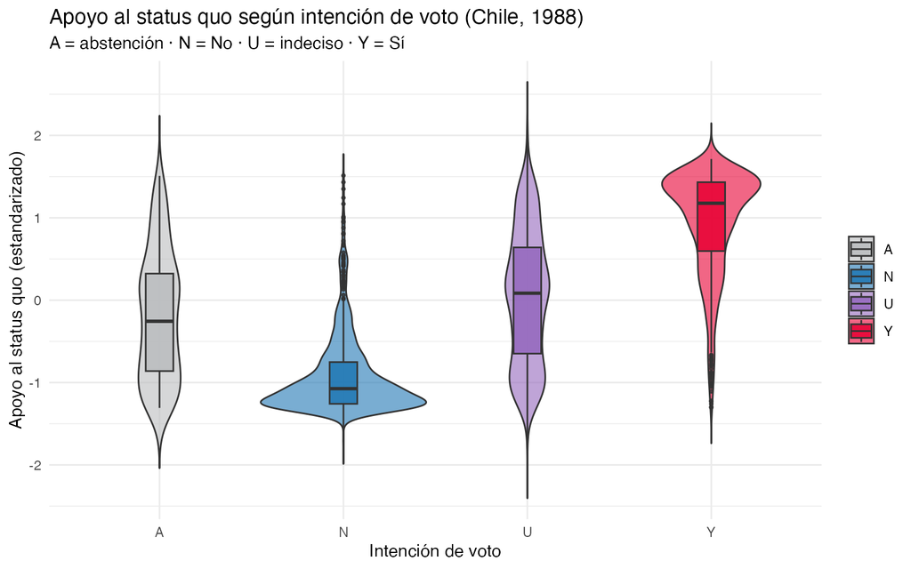

Figura 1: Distribución del apoyo al status quo según intención de voto

```r
chile |>
  filter(!is.na(vote), !is.na(statusquo)) |>
  ggplot(aes(x = vote, y = statusquo, fill = vote)) +
  geom_violin(alpha = 0.6, trim = FALSE) +
  geom_boxplot(width = 0.15, alpha = 0.85, outlier.size = 0.7) +
  scale_fill_manual(values = c("A" = "#babcbe", "N" = "#1f77b4",
                               "U" = "#9467bd", "Y" = "#e70033")) +
  labs(
    title = "Apoyo al status quo según intención de voto (Chile, 1988)",
    subtitle = "A = abstención · N = No · U = indeciso · Y = Sí",
    x = "Intención de voto",
    y = "Apoyo al status quo (estandarizado)",
    fill = NULL
  ) +
  theme_minimal()
```

Lectura: el voto Sí (apoyo a Pinochet) y el voto No están claramente polarizados sobre el eje del status quo. Los indecisos (U) y abstencionistas (A) ocupan el centro.

## 5.2 Apoyo por edad y educación

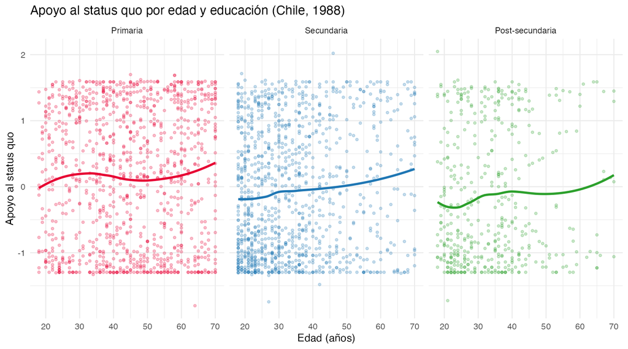

Figura 2: Apoyo al status quo por edad, separado por nivel educativo

```r
chile_anotado |>
  filter(!is.na(statusquo), !is.na(educación)) |>
  ggplot(aes(x = age, y = statusquo, colour = educación)) +
  geom_point(alpha = 0.25, size = 1) +
  geom_smooth(method = "loess", se = FALSE, linewidth = 1.1) +
  facet_wrap(~ educación) +
  scale_colour_manual(values = c("Primaria" = "#e70033",
                                 "Secundaria" = "#1f77b4",
                                 "Post-secundaria" = "#2ca02c")) +
  labs(
    title = "Apoyo al status quo por edad y educación (Chile, 1988)",
    x = "Edad (años)",
    y = "Apoyo al status quo",
    colour = "Educación"
  ) +
  theme_minimal() +
  theme(legend.position = "none")
```

**AdvertenciaSi nunca han trabajado con código**

El signo `+` en ggplot2 significa “añade esta capa al gráfico”. Empezamos con un lienzo (`ggplot()`) y vamos sumando: puntos, suavizados, etiquetas, tema. Cuando algo se ve raro, a menudo falta un `+` entre líneas.

## 5.3 Composición del voto por región

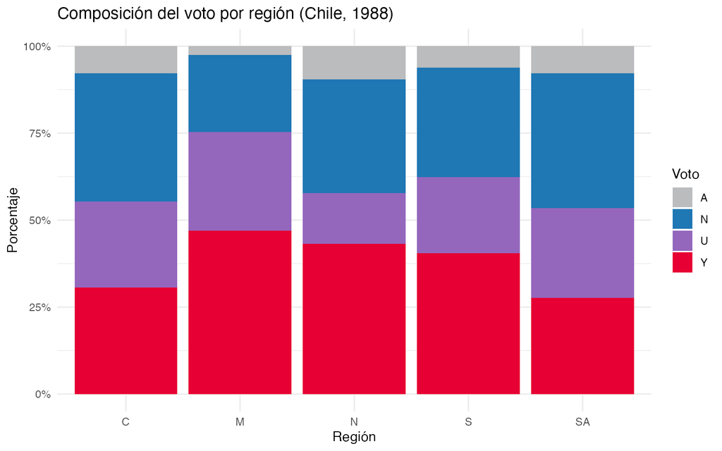

Figura 3: Distribución porcentual del voto por región

```r
chile |>
  filter(!is.na(vote)) |>
  count(region, vote) |>
  group_by(region) |>
  mutate(prop = n / sum(n)) |>
  ggplot(aes(x = region, y = prop, fill = vote)) +
  geom_col(position = "fill") +
  scale_y_continuous(labels = scales::percent_format()) +
  scale_fill_manual(values = c("A" = "#babcbe", "N" = "#1f77b4",
                               "U" = "#9467bd", "Y" = "#e70033")) +
  labs(
    title = "Composición del voto por región (Chile, 1988)",
    x = "Región",
    y = "Porcentaje",
    fill = "Voto"
  ) +
  theme_minimal()
```

**Prueben ustedes**: cambien `position = "fill"` por `position = "dodge"`. ¿Cómo cambia la lectura?

# 6 Modelo lineal: ¿quién apoyaba el régimen?

R trae la función `lm()` para ajustar modelos lineales. Es la herramienta básica de la inferencia estadística.

**TipSi han usado SPSS o Stata**

`lm()` equivale a *Analyze > Regression > Linear* en SPSS, o `regress` en Stata. La fórmula `Y ~ X1 + X2` se lee “Y en función de X1 y X2”. `summary()` devuelve los coeficientes, errores estándar, valores *t* y *p* que ya conocen.

## 6.1 Apoyo al status quo en función de variables socioeconómicas

```r
modelo <- lm(statusquo ~ income + age + sex + education,
             data = chile)
summary(modelo)
```

```
Call:
lm(formula = statusquo ~ income + age + sex + education, data = chile)

Residuals:
     Min       1Q   Median       3Q      Max
-1.67262 -0.91146 -0.08131  0.93493  2.07015

Coefficients:
              Estimate Std. Error t value Pr(>|t|)
(Intercept) -3.927e-02  7.089e-02  -0.554  0.57965
income       2.893e-06  5.493e-07   5.266 1.51e-07 ***
age          4.492e-03  1.412e-03   3.181  0.00149 **
sexM        -1.210e-01  3.885e-02  -3.116  0.00186 **
educationS  -2.516e-01  4.631e-02  -5.433 6.06e-08 ***
educationPS -4.472e-01  6.479e-02  -6.901 6.46e-12 ***
---
Signif. codes:  0 '***' 0.001 '**' 0.01 '*' 0.05 '.' 0.1 ' ' 1

Residual standard error: 0.9819 on 2575 degrees of freedom
  (119 observations deleted due to missingness)
Multiple R-squared:  0.03956,   Adjusted R-squared:  0.03769
F-statistic: 21.21 on 5 and 2575 DF,  p-value: < 2.2e-16
```

## 6.2 Coeficientes en una tabla limpia

```r
library(broom)
tidy(modelo, conf.int = TRUE) |>
  mutate(across(where(is.numeric), \(x) round(x, 4)))
```

```
# A tibble: 6 × 7
  term        estimate std.error statistic p.value conf.low conf.high
  <chr>          <dbl>     <dbl>     <dbl>   <dbl>    <dbl>     <dbl>
1 (Intercept)  -0.0393    0.0709    -0.554  0.580   -0.178     0.0997
2 income        0         0          5.27   0        0         0
3 age           0.0045    0.0014     3.18   0.0015   0.0017    0.0073
4 sexM         -0.121     0.0389    -3.12   0.0019  -0.197    -0.0449
5 educationS   -0.252     0.0463    -5.43   0       -0.342    -0.161
6 educationPS  -0.447     0.0648    -6.90   0       -0.574    -0.320
```

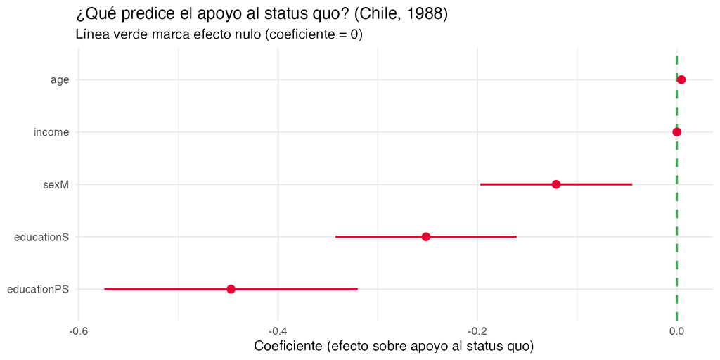

Figura 4: Coeficientes del modelo con intervalos de confianza al 95%

```r
tidy(modelo, conf.int = TRUE) |>
  filter(term != "(Intercept)") |>
  ggplot(aes(x = estimate, y = reorder(term, estimate))) +
  geom_vline(xintercept = 0, linetype = "dashed",
             colour = "#38B44A", linewidth = 0.8) +
  geom_pointrange(aes(xmin = conf.low, xmax = conf.high),
                  colour = "#e70033", linewidth = 0.8) +
  labs(
    title = "¿Qué predice el apoyo al status quo? (Chile, 1988)",
    subtitle = "Línea verde marca efecto nulo (coeficiente = 0)",
    x = "Coeficiente (efecto sobre apoyo al status quo)",
    y = NULL
  ) +
  theme_minimal()
```

## 6.3 Efectos marginales: predicciones del modelo

Los coeficientes cuentan la mitad de la historia. Lo que comunica mejor un modelo a una audiencia no técnica son las **predicciones marginales**: dado un valor específico de una variable y manteniendo las demás constantes (en su media o moda), ¿qué apoyo al *status quo* predice el modelo? El paquete `ggeffects` calcula estas predicciones con intervalos de confianza en un solo paso y las devuelve listas para `ggplot2`.

```r
library(ggeffects)
```

### 6.3.1 Efecto marginal del ingreso

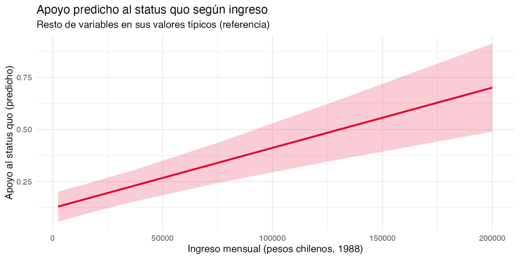

Figura 5: Apoyo al status quo según ingreso, manteniendo edad, sexo y educación en sus valores típicos

```r
pred_income <- ggpredict(modelo, terms = "income [all]")

ggplot(pred_income, aes(x = x, y = predicted)) +
  geom_ribbon(aes(ymin = conf.low, ymax = conf.high),
              fill = "#e70033", alpha = 0.20) +
  geom_line(colour = "#e70033", linewidth = 1) +
  labs(
    title = "Apoyo predicho al status quo según ingreso",
    subtitle = "Resto de variables en sus valores típicos (referencia)",
    x = "Ingreso mensual (pesos chilenos, 1988)",
    y = "Apoyo al status quo (predicho)"
  ) +
  theme_minimal()
```

Pendiente positiva suave: más ingreso, algo más de apoyo al régimen — coherente con el coeficiente pero ahora expresado en la escala original de la variable dependiente.

### 6.3.2 Efecto marginal de la edad, separado por sexo

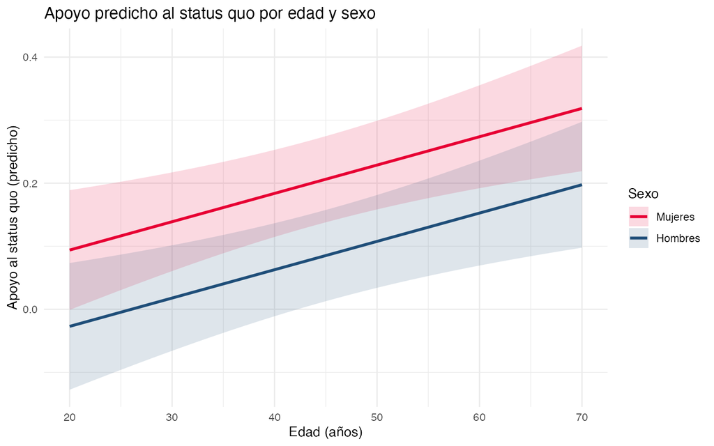

Figura 6: Apoyo al status quo según edad, separado por sexo, con intervalo de confianza 95%

```r
pred_age_sex <- ggpredict(modelo, terms = c("age [20:70]", "sex"))

ggplot(pred_age_sex, aes(x = x, y = predicted, colour = group, fill = group)) +
  geom_ribbon(aes(ymin = conf.low, ymax = conf.high),
              alpha = 0.15, colour = NA) +
  geom_line(linewidth = 1.1) +
  scale_colour_manual(values = c("F" = "#e70033", "M" = "#1f4e79"),
                      labels = c("F" = "Mujeres", "M" = "Hombres")) +
  scale_fill_manual(values = c("F" = "#e70033", "M" = "#1f4e79"),
                    labels = c("F" = "Mujeres", "M" = "Hombres")) +
  labs(
    title = "Apoyo predicho al status quo por edad y sexo",
    x = "Edad (años)",
    y = "Apoyo al status quo (predicho)",
    colour = "Sexo",
    fill = "Sexo"
  ) +
  theme_minimal()
```

### 6.3.3 Efecto marginal de la educación

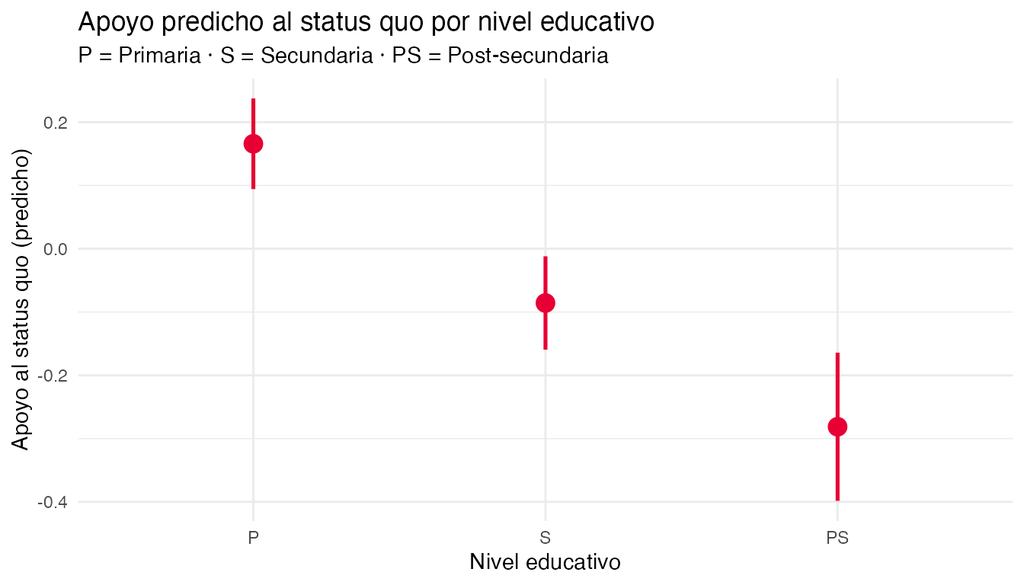

Figura 7: Apoyo al status quo predicho por nivel educativo, con intervalo de confianza 95%

```r
pred_edu <- ggpredict(modelo, terms = "education")

ggplot(pred_edu, aes(x = x, y = predicted)) +
  geom_pointrange(aes(ymin = conf.low, ymax = conf.high),
                  colour = "#e70033", linewidth = 0.9, size = 0.8) +
  labs(
    title = "Apoyo predicho al status quo por nivel educativo",
    subtitle = "P = Primaria · S = Secundaria · PS = Post-secundaria",
    x = "Nivel educativo",
    y = "Apoyo al status quo (predicho)"
  ) +
  theme_minimal()
```

**TipCoeficientes vs. predicciones marginales**

Un coeficiente dice *cuánto cambia Y por unidad de X, ceteris paribus*. Una predicción marginal dice *qué valor de Y predice el modelo para este perfil concreto*. Para una audiencia no técnica (comités, prensa, entrevistas), las predicciones marginales comunican mejor porque están en la escala de la variable original — sin logaritmos, sin log-odds, sin “unidad estándar”.

# 7 Regresión logística sobre el voto

El modelo lineal de arriba trata `statusquo` como variable continua. Cuando la dependiente es **categórica** (Sí / No / Indeciso / Abstención), corresponde una **regresión logística**. Trabajaremos primero la versión **binaria** (voto Sí vs. voto No) y luego la **multinomial** (las cuatro categorías).

## 7.1 Preparar una variable binaria

La binomización no es inocua. Fundir *No + Abstención + Indeciso* en una sola categoría “no-Sí” mezcla **oposición explícita** con **no-respuesta** — tres posiciones políticamente distintas. La pregunta sustantiva interesante es: *entre quienes sí tomaron posición, ¿qué predice el voto Sí frente al No?* Por eso restringimos el modelo a las dos categorías que constituyen una elección polar.

```r
chile_glm <- chile |>
  filter(vote %in% c("Y", "N")) |>        # solo quienes tomaron posición
  mutate(voto_si = as.integer(vote == "Y"))

chile_glm |>
  count(vote, voto_si) |>
  arrange(vote)
```

```
# A tibble: 2 × 3
  vote  voto_si     n
  <fct>   <int> <int>
1 N           0   889
2 Y           1   868
```

Quedan aproximadamente **1 757 casos** (868 Sí + 889 No), excluyendo a 588 indecisos, 187 abstencionistas y 168 sin respuesta registrada. El modelo estimará probabilidad de voto Sí **condicional a haber tomado posición**.

## 7.2 Ajustar el modelo logístico

```r
m_logit <- glm(voto_si ~ age + sex + education + income + statusquo,
               data = chile_glm, family = binomial)
summary(m_logit)
```

```
Call:
glm(formula = voto_si ~ age + sex + education + income + statusquo,
    family = binomial, data = chile_glm)

Coefficients:
              Estimate Std. Error z value Pr(>|z|)
(Intercept)  1.007e+00  3.757e-01   2.680  0.00736 **
age          1.249e-03  7.419e-03   0.168  0.86632
sexM        -5.725e-01  2.026e-01  -2.826  0.00471 **
educationS  -6.281e-01  2.415e-01  -2.601  0.00930 **
educationPS -9.605e-01  3.421e-01  -2.807  0.00500 **
income      -2.350e-06  2.783e-06  -0.844  0.39840
statusquo    3.183e+00  1.468e-01  21.687  < 2e-16 ***
---
Signif. codes:  0 '***' 0.001 '**' 0.01 '*' 0.05 '.' 0.1 ' ' 1

(Dispersion parameter for binomial family taken to be 1)

    Null deviance: 2360.29  on 1702  degrees of freedom
Residual deviance:  707.52  on 1696  degrees of freedom
  (54 observations deleted due to missingness)
AIC: 721.52

Number of Fisher Scoring iterations: 6
```

Los coeficientes están en **log-odds**: son difíciles de interpretar en su escala original. Una tabla con intervalos de confianza y la exponenciación a **odds ratios** es más legible:

```r
tidy(m_logit, conf.int = TRUE, exponentiate = TRUE) |>
  mutate(across(where(is.numeric), \(x) round(x, 3)))
```

```
# A tibble: 7 × 7
  term        estimate std.error statistic p.value conf.low conf.high
  <chr>          <dbl>     <dbl>     <dbl>   <dbl>    <dbl>     <dbl>
1 (Intercept)    2.74      0.376     2.68    0.007    1.32      5.76
2 age            1.00      0.007     0.168   0.866    0.987     1.02
3 sexM           0.564     0.203    -2.83    0.005    0.378     0.838
4 educationS     0.534     0.242    -2.60    0.009    0.331     0.855
5 educationPS    0.383     0.342    -2.81    0.005    0.194     0.742
6 income         1         0        -0.844   0.398    1         1
7 statusquo     24.1       0.147    21.7     0       18.3      32.6
```

Con `exponentiate = TRUE`, `estimate` pasa a ser **odds ratio**: valores mayores que 1 aumentan la probabilidad de votar Sí; menores que 1 la disminuyen; igual a 1 indica ausencia de efecto.

## 7.3 Coefplot con línea de referencia en el cero

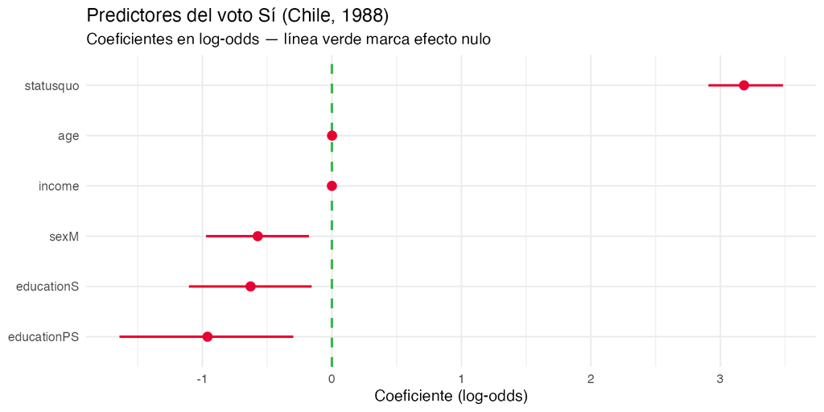

Figura 8: Coeficientes logísticos con intervalo de confianza 95% — línea verde marca el cero (log-odds)

```r
tidy(m_logit, conf.int = TRUE) |>
  filter(term != "(Intercept)") |>
  ggplot(aes(x = estimate, y = reorder(term, estimate))) +
  geom_vline(xintercept = 0, linetype = "dashed",
             colour = "#38B44A", linewidth = 0.8) +
  geom_pointrange(aes(xmin = conf.low, xmax = conf.high),
                  colour = "#e70033", linewidth = 0.8) +
  labs(
    title = "Predictores del voto Sí (Chile, 1988)",
    subtitle = "Coeficientes en log-odds — línea verde marca efecto nulo",
    x = "Coeficiente (log-odds)",
    y = NULL
  ) +
  theme_minimal()
```

## 7.4 Efectos marginales del modelo logístico

Los efectos marginales en la escala original (probabilidad de 0 a 1) son la forma más legible de comunicar un modelo logístico.

### 7.4.1 Probabilidad predicha de voto Sí según `statusquo`

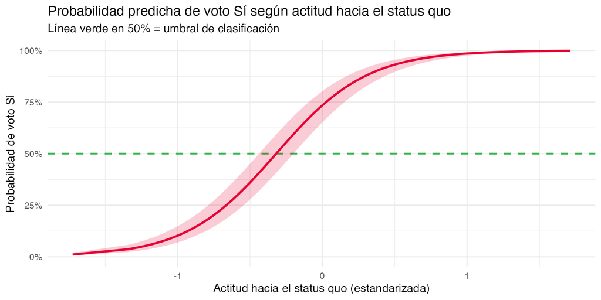

Figura 9: Probabilidad predicha de voto Sí según apoyo al status quo, con intervalo de confianza 95%

```r
pred_sq <- ggpredict(m_logit, terms = "statusquo [all]")

ggplot(pred_sq, aes(x = x, y = predicted)) +
  geom_hline(yintercept = 0.5, linetype = "dashed",
             colour = "#38B44A", linewidth = 0.8) +
  geom_ribbon(aes(ymin = conf.low, ymax = conf.high),
              fill = "#e70033", alpha = 0.20) +
  geom_line(colour = "#e70033", linewidth = 1) +
  scale_y_continuous(labels = scales::percent_format(accuracy = 1),
                     limits = c(0, 1)) +
  labs(
    title = "Probabilidad predicha de voto Sí según actitud hacia el status quo",
    subtitle = "Línea verde en 50% = umbral de clasificación",
    x = "Actitud hacia el status quo (estandarizada)",
    y = "Probabilidad de voto Sí"
  ) +
  theme_minimal()
```

### 7.4.2 Probabilidad de voto Sí por nivel educativo

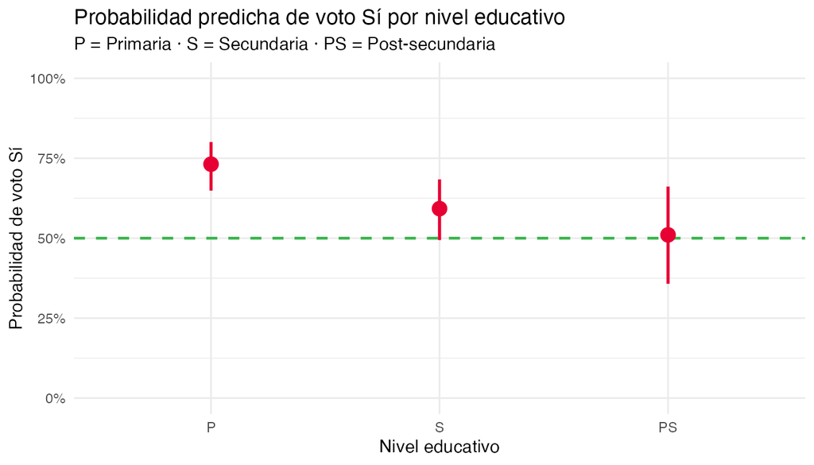

Figura 10: Probabilidad predicha de voto Sí por nivel educativo — línea verde = nivel basal del 50%

```r
pred_edu_glm <- ggpredict(m_logit, terms = "education")

ggplot(pred_edu_glm, aes(x = x, y = predicted)) +
  geom_hline(yintercept = 0.5, linetype = "dashed",
             colour = "#38B44A", linewidth = 0.8) +
  geom_pointrange(aes(ymin = conf.low, ymax = conf.high),
                  colour = "#e70033", linewidth = 0.9, size = 0.8) +
  scale_y_continuous(labels = scales::percent_format(accuracy = 1),
                     limits = c(0, 1)) +
  labs(
    title = "Probabilidad predicha de voto Sí por nivel educativo",
    subtitle = "P = Primaria · S = Secundaria · PS = Post-secundaria",
    x = "Nivel educativo",
    y = "Probabilidad de voto Sí"
  ) +
  theme_minimal()
```

### 7.4.3 Probabilidad de voto Sí por edad, separada por sexo

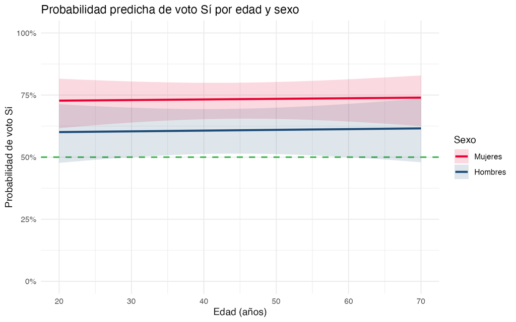

Figura 11: Probabilidad predicha de voto Sí por edad y sexo, con intervalo de confianza 95%

```r
pred_age_sex_glm <- ggpredict(m_logit, terms = c("age [20:70]", "sex"))

ggplot(pred_age_sex_glm, aes(x = x, y = predicted, colour = group, fill = group)) +
  geom_hline(yintercept = 0.5, linetype = "dashed",
             colour = "#38B44A", linewidth = 0.8) +
  geom_ribbon(aes(ymin = conf.low, ymax = conf.high),
              alpha = 0.15, colour = NA) +
  geom_line(linewidth = 1.1) +
  scale_colour_manual(values = c("F" = "#e70033", "M" = "#1f4e79"),
                      labels = c("F" = "Mujeres", "M" = "Hombres")) +
  scale_fill_manual(values = c("F" = "#e70033", "M" = "#1f4e79"),
                    labels = c("F" = "Mujeres", "M" = "Hombres")) +
  scale_y_continuous(labels = scales::percent_format(accuracy = 1),
                     limits = c(0, 1)) +
  labs(
    title = "Probabilidad predicha de voto Sí por edad y sexo",
    x = "Edad (años)",
    y = "Probabilidad de voto Sí",
    colour = "Sexo",
    fill = "Sexo"
  ) +
  theme_minimal()
```

## 7.5 Regresión multinomial: las cuatro categorías de voto

```r
library(nnet)

chile_multi <- chile |>
  mutate(vote_multi = factor(vote,
                             levels = c("N", "Y", "A", "U"),
                             labels = c("No", "Sí", "Abstención", "Indeciso")))

m_multi <- multinom(vote_multi ~ age + sex + education + income + statusquo,
                    data = chile_multi)
```

```r
summary(m_multi)
```

```
Call:
multinom(formula = vote_multi ~ age + sex + education + income +
    statusquo, data = chile_multi)

Coefficients:
           (Intercept)          age       sexM educationS educationPS
Sí           0.6472278  0.011314365 -0.7750583 -0.4186292  -0.7273675
Abstención   0.2477105 -0.008890955 -0.6894388  0.2780296  -0.1734169
Indeciso     1.0584816  0.016981329 -0.9390310 -0.3226781  -1.0526850
                  income statusquo
Sí         -1.811176e-06  3.684375
Abstención -3.921962e-06  1.810129
Indeciso   -7.244757e-06  2.140755

Std. Errors:
            (Intercept)         age         sexM   educationS  educationPS
Sí         5.002333e-05 0.002430207 2.293487e-05 1.569234e-05 3.787010e-07
Abstención 7.099450e-05 0.003042817 3.177019e-05 3.409660e-05 2.981462e-06
Indeciso   4.254758e-05 0.002080101 2.004385e-05 1.356176e-05 1.503751e-06
                 income    statusquo
Sí         1.957172e-06 1.782023e-05
Abstención 2.266473e-06 3.051573e-05
Indeciso   1.936064e-06 7.978259e-05

Residual Deviance: 4037.37
AIC: 4079.37
```

### 7.5.1 Probabilidades multinomiales predichas por `statusquo`

La gráfica más informativa del multinomial muestra **cómo cambia la probabilidad de cada categoría** según la variable clave — el apoyo al status quo.

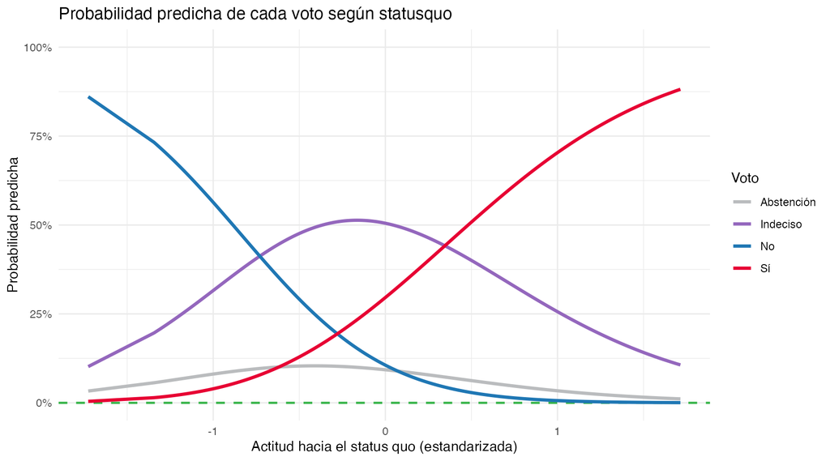

Figura 12: Probabilidades predichas de cada categoría de voto según statusquo

```r
pred_multi_sq <- ggpredict(m_multi, terms = "statusquo [all]")

colores_voto <- c("No" = "#1f77b4",
                  "Sí" = "#e70033",
                  "Abstención" = "#babcbe",
                  "Indeciso" = "#9467bd")

ggplot(pred_multi_sq, aes(x = x, y = predicted, colour = response.level)) +
  geom_hline(yintercept = 0, linetype = "dashed",
             colour = "#38B44A", linewidth = 0.8) +
  geom_line(linewidth = 1.2) +
  scale_colour_manual(values = colores_voto) +
  scale_y_continuous(labels = scales::percent_format(accuracy = 1),
                     limits = c(0, 1)) +
  labs(
    title = "Probabilidad predicha de cada voto según statusquo",
    x = "Actitud hacia el status quo (estandarizada)",
    y = "Probabilidad predicha",
    colour = "Voto"
  ) +
  theme_minimal()
```

Lectura: a medida que sube `statusquo`, la probabilidad del voto **Sí** crece casi monotónica; la del **No** decrece; los indecisos y abstencionistas forman una banda intermedia que se contrae en los extremos. Esto es lo que un modelo multinomial captura y una regresión binaria aplanaría.

### 7.5.2 Probabilidades multinomiales por nivel educativo

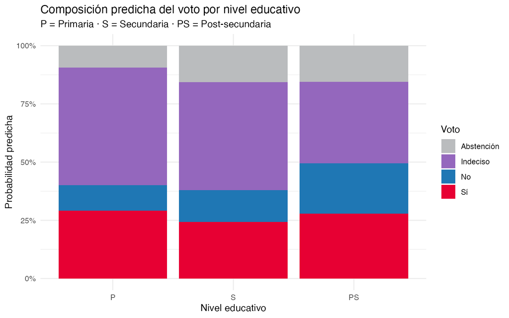

Figura 13: Probabilidades predichas de cada voto por nivel educativo

```r
pred_multi_edu <- ggpredict(m_multi, terms = "education")

ggplot(pred_multi_edu, aes(x = x, y = predicted, fill = response.level)) +
  geom_col(position = "fill") +
  scale_fill_manual(values = colores_voto) +
  scale_y_continuous(labels = scales::percent_format()) +
  labs(
    title = "Composición predicha del voto por nivel educativo",
    subtitle = "P = Primaria · S = Secundaria · PS = Post-secundaria",
    x = "Nivel educativo",
    y = "Probabilidad predicha",
    fill = "Voto"
  ) +
  theme_minimal()
```

# 8 Comparación de dos corpus: Cervantes (1605) vs. Galdós (1887)

Esta sección compara el vocabulario de dos novelas del canon hispano. La lógica que veremos es transferible a cualquier comparación textual: prensa de dos épocas, discursos de dos presidentes, transcripciones de dos conjuntos de entrevistas, manifiestos de dos partidos. Cerraremos con un mini-ejemplo aplicado a discursos inaugurales presidenciales.

**NotaLa lógica subyacente — texto como datos**

El análisis cuantitativo de texto pasa por **cuatro pasos casi siempre iguales** (Silge & Robinson, *Text Mining with R*; Grimmer, Roberts & Stewart, *Text as Data*, 2022):

1. **Tokenizar** — partir el texto en unidades (palabras, bigramas, oraciones). Cada token pasa a ser una fila.
2. **Limpiar** — pasar a minúsculas, remover puntuación y números, eliminar palabras vacías (*stopwords*) que aportan poco contenido.
3. **Contar** — frecuencias absolutas y relativas por documento.
4. **Comparar** — entre documentos, identificar qué palabras los distinguen (TF-IDF, log-ratio, *keyness*).

Trabajaremos los cuatro pasos sobre el par Quijote / Fortunata.

## 8.1 Paquetes para texto

```r
library(gutenbergr)  # acceso al Proyecto Gutenberg
library(tidytext)    # texto como tabla ordenada (Silge & Robinson)
library(stopwords)   # palabras vacías por idioma
```

## 8.2 Cargar las dos obras (con normalización de encoding)

Los dos textos vienen pre-descargados en `datos/` para que la sesión funcione sin depender de la red de la sala. La función `cargar_obra()` los lee del disco; si faltaran, los bajaría del Proyecto Gutenberg.

```r
cargar_obra <- function(id, ruta_local) {
  if (file.exists(ruta_local)) {
    readRDS(ruta_local)
  } else {
    obra <- gutenbergr::gutenberg_download(id)
    # Normalizar a UTF-8 al bajar fresh (algunos textos del Proyecto
    # Gutenberg vienen en Latin1 y romperían las tildes al tokenizar).
    obra$text <- iconv(obra$text, from = "", to = "UTF-8", sub = "")
    saveRDS(obra, ruta_local)
    obra
  }
}

quijote   <- cargar_obra(2000,  "datos/quijote.rds")     # Cervantes, 1605
fortunata <- cargar_obra(17013, "datos/fortunata.rds")   # Galdós, 1887

c(quijote   = nrow(quijote),
  fortunata = nrow(fortunata))
```

```
  quijote fortunata
    37671     41853
```

**ImportanteNota técnica: encoding de textos del Proyecto Gutenberg**

Algunos textos viejos del Proyecto Gutenberg vienen codificados en **Latin1 / ISO-8859-1** en vez de UTF-8. Si los procesaran tal cual, las tildes y eñes se romperían y palabras como `también` aparecerían truncadas a `tambi`. La normalización a UTF-8 se hace con `iconv()`:

```r
fortunata$text <- iconv(fortunata$text, from = "latin1", to = "UTF-8")
```

En este taller los `.rds` ya están normalizados a UTF-8, pero conviene saber que existe esta trampa: cuando vean tokens en español que parezcan mutilados, sospechen del *encoding* primero.

## 8.3 Construir un corpus etiquetado y tokenizar

Marcamos cada texto con su autor y unimos en una sola tabla. Esa estructura *tidy* (un corpus largo con una columna que identifica al documento) es la base para aplicar los mismos verbos a las dos obras.

```r
corpus <- bind_rows(
  quijote   |> mutate(obra = "Quijote (Cervantes, 1605)"),
  fortunata |> mutate(obra = "Fortunata (Galdós, 1887)")
)

palabras <- corpus |>
  unnest_tokens(palabra, text)

palabras |>
  count(obra, name = "tokens")
```

```
# A tibble: 2 × 2
  obra                      tokens
  <chr>                      <int>
1 Fortunata (Galdós, 1887)  394820
2 Quijote (Cervantes, 1605) 383636
```

`unnest_tokens(palabra, text)` toma cada fila de `text` y la expande en muchas filas, una por *token*, en una nueva columna `palabra`. Pasa a minúsculas y remueve puntuación por defecto. Es la operación pivote del paquete `tidytext`.

## 8.4 Paso intermedio: ¿qué pasa SIN remover stopwords?

Antes de limpiar, vale la pena ver el resultado crudo. Las palabras más frecuentes son siempre las mismas en cualquier texto en español: artículos, preposiciones y conjunciones. Esto nos dice poco sobre el contenido.

```r
palabras |>
  group_by(obra) |>
  count(palabra, sort = TRUE) |>
  slice_max(n, n = 5, with_ties = FALSE)
```

```
# A tibble: 10 × 3
# Groups:   obra [2]
   obra                      palabra     n
   <chr>                     <chr>   <int>
 1 Fortunata (Galdós, 1887)  de      18237
 2 Fortunata (Galdós, 1887)  que     15611
 3 Fortunata (Galdós, 1887)  la      14495
 4 Fortunata (Galdós, 1887)  y       13276
 5 Fortunata (Galdós, 1887)  a        9937
 6 Quijote (Cervantes, 1605) que     20769
 7 Quijote (Cervantes, 1605) de      18410
 8 Quijote (Cervantes, 1605) y       18272
 9 Quijote (Cervantes, 1605) la      10492
10 Quijote (Cervantes, 1605) a        9875
```

`de`, `que`, `la`, `y`, `a`… las mismas en ambas obras. El siguiente paso (remover *stopwords*) es el que hace visible el contenido sustantivo.

## 8.5 Frecuencias relativas tras remover *stopwords*

Las **palabras vacías** o *stopwords* son aquellas de altísima frecuencia y bajísima carga semántica (`el`, `la`, `de`, `que`, `y`…). El paquete `stopwords` provee listas curadas para múltiples idiomas y fuentes; usamos la lista ISO en español.

```r
vacias_es <- tibble(palabra = stopwords("es", source = "stopwords-iso"))

frecuencias <- palabras |>
  anti_join(vacias_es, by = "palabra") |>
  filter(nchar(palabra) > 2,
         !grepl("[0-9]", palabra)) |>
  count(obra, palabra, name = "n") |>
  group_by(obra) |>
  mutate(frec = n / sum(n)) |>          # frecuencia relativa
  ungroup()

frecuencias |>
  group_by(obra) |>
  slice_max(n, n = 10, with_ties = FALSE) |>
  arrange(obra, desc(n))
```

```
# A tibble: 20 × 4
# Groups:   obra [2]
   obra                      palabra       n    frec
   <chr>                     <chr>     <int>   <dbl>
 1 Fortunata (Galdós, 1887)  fortunata   866 0.00575
 2 Fortunata (Galdós, 1887)  casa        865 0.00575
 3 Fortunata (Galdós, 1887)  doña        714 0.00474
 4 Fortunata (Galdós, 1887)  jacinta     571 0.00379
 5 Fortunata (Galdós, 1887)  mujer       542 0.00360
 6 Fortunata (Galdós, 1887)  lupe        521 0.00346
 7 Fortunata (Galdós, 1887)  hombre      483 0.00321
 8 Fortunata (Galdós, 1887)  señora      470 0.00312
 9 Fortunata (Galdós, 1887)  dios        460 0.00306
10 Fortunata (Galdós, 1887)  cabeza      441 0.00293
11 Quijote (Cervantes, 1605) don        2714 0.0191
12 Quijote (Cervantes, 1605) quijote    2241 0.0158
13 Quijote (Cervantes, 1605) sancho     2174 0.0153
14 Quijote (Cervantes, 1605) señor      1065 0.00749
15 Quijote (Cervantes, 1605) respondió  1063 0.00747
16 Quijote (Cervantes, 1605) merced      900 0.00633
17 Quijote (Cervantes, 1605) caballero   677 0.00476
18 Quijote (Cervantes, 1605) dios        531 0.00373
19 Quijote (Cervantes, 1605) señora      518 0.00364
20 Quijote (Cervantes, 1605) cosa        447 0.00314
```

`anti_join(vacias_es)` es elegante: en una sola línea, descarta cualquier fila cuya `palabra` esté en la lista de vacías. Es la forma *tidy* de “remueve estos tokens”.

## 8.6 Palabras distintivas (log-ratio)

Las frecuencias por separado todavía mezclan tres cosas: (a) palabras que ambas obras usan mucho (verbos comunes, palabras de la vida cotidiana), (b) nombres propios de cada obra, (c) léxico realmente característico de cada una. Para aislar (b) y (c) necesitamos una **medida de contraste**.

La más simple es la **razón logarítmica de frecuencias relativas** (Silge & Robinson, cap. 3; idea original en Monroe, Colaresi & Quinn, 2008, “Fightin’ words”):

$$\text{log-ratio}(w) = \log_2 \frac{\text{frec}(w \mid A) + \varepsilon}{\text{frec}(w \mid B) + \varepsilon}$$

- **Positivo y grande** → la palabra `w` es **mucho más típica de A** que de B.
- **Negativo y grande** → mucho más típica de B.
- **Cercano a 0** → ambas obras la usan en proporción similar.
- El $\varepsilon = 10^{-6}$ es una constante pequeña para evitar dividir por cero cuando una palabra aparece en una obra y no en la otra (técnica conocida como *additive smoothing*).

```r
distintivas <- frecuencias |>
  select(obra, palabra, frec) |>
  pivot_wider(names_from = obra, values_from = frec, values_fill = 0) |>
  rename(frec_quijote   = `Quijote (Cervantes, 1605)`,
         frec_fortunata = `Fortunata (Galdós, 1887)`) |>
  mutate(
    total = frec_quijote + frec_fortunata,
    log_ratio = log2((frec_quijote + 1e-6) / (frec_fortunata + 1e-6))
  ) |>
  filter(total > 5e-4)   # piso de frecuencia conjunta para evitar palabras anecdóticas

top_quijote   <- distintivas |> slice_max(log_ratio, n = 10)
top_fortunata <- distintivas |> slice_min(log_ratio, n = 10)

bind_rows(
  top_quijote   |> mutate(lado = "Quijote"),
  top_fortunata |> mutate(lado = "Fortunata")
) |>
  select(lado, palabra, frec_quijote, frec_fortunata, log_ratio)
```

```
# A tibble: 20 × 5
   lado      palabra     frec_quijote frec_fortunata log_ratio
   <chr>     <chr>              <dbl>          <dbl>     <dbl>
 1 Quijote   dulcinea         0.00201     0               11.0
 2 Quijote   sancho           0.0153      0.00000664      11.0
 3 Quijote   desta            0.00167     0               10.7
 4 Quijote   mesmo            0.00154     0               10.6
 5 Quijote   vos              0.00149     0               10.5
 6 Quijote   rocinante        0.00146     0               10.5
 7 Quijote   vuesa            0.00143     0               10.5
 8 Quijote   barbero          0.00120     0               10.2
 9 Quijote   toboso           0.00116     0               10.2
10 Quijote   andantes         0.00114     0               10.2
11 Fortunata fortunata        0           0.00575        -12.5
12 Fortunata jacinta          0           0.00379        -11.9
13 Fortunata lupe             0           0.00346        -11.8
14 Fortunata guillermina      0           0.00213        -11.1
15 Fortunata rubín            0           0.00207        -11.0
16 Fortunata maxi             0           0.00202        -11.0
17 Fortunata maximiliano      0           0.00195        -10.9
18 Fortunata mauricia         0           0.00126        -10.3
19 Fortunata barbarita        0           0.00126        -10.3
20 Fortunata ideas            0           0.00106        -10.0
```

El filtro `total > 5e-4` deja fuera palabras de frecuencia conjunta extremadamente baja: queremos contraste sobre vocabulario que **realmente aparece**, no sobre rarezas que distorsionan el log-ratio por el efecto del suavizado.

## 8.7 Visualizar las palabras distintivas

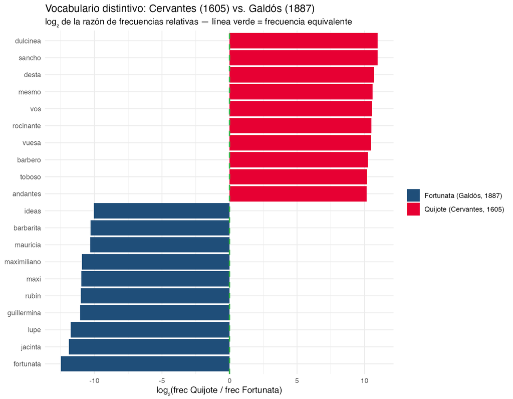

Figura 14: Palabras más distintivas de cada novela (log-ratio de frecuencias relativas)

```r
bind_rows(
  top_quijote   |> mutate(lado = "Quijote (Cervantes, 1605)"),
  top_fortunata |> mutate(lado = "Fortunata (Galdós, 1887)")
) |>
  ggplot(aes(x = log_ratio,
             y = reorder(palabra, log_ratio),
             fill = lado)) +
  geom_col() +
  geom_vline(xintercept = 0, linetype = "dashed",
             colour = "#38B44A", linewidth = 0.8) +
  scale_fill_manual(values = c("Quijote (Cervantes, 1605)" = "#e70033",
                               "Fortunata (Galdós, 1887)"  = "#1f4e79")) +
  labs(
    title = "Vocabulario distintivo: Cervantes (1605) vs. Galdós (1887)",
    subtitle = "log₂ de la razón de frecuencias relativas — línea verde = frecuencia equivalente",
    x = "log₂(frec Quijote / frec Fortunata)",
    y = NULL,
    fill = NULL
  ) +
  theme_minimal()
```

**TipSi han hecho análisis de discurso cualitativo**

Lo que en grounded theory llamarían “códigos *in vivo*” — términos del corpus que cargan sentido propio — emerge aquí como palabras de **alto log-ratio**: el método cuantitativo no reemplaza la lectura cercana, pero le señala dónde mirar.

## 8.8 Aplicación: discursos inaugurales presidenciales

La misma lógica funciona sobre **discursos políticos**. El paquete `quanteda` (Benoit et al., 2018) trae un corpus de discursos inaugurales de presidentes de EEUU (1789–presente) y una función `textstat_keyness()` que generaliza la idea de log-ratio a una prueba estadística (chi-cuadrado o log-likelihood). Es lo que usaríamos en un análisis publicable.

El siguiente bloque es **demostrativo** (no se ejecuta por defecto para no añadir paquetes pesados al taller). Para correrlo: `install.packages(c("quanteda", "quanteda.textstats", "quanteda.textplots"))`.

```r
library(quanteda)
library(quanteda.textstats)
library(quanteda.textplots)

# 1. Corpus de discursos inaugurales (viene incluido en quanteda)
corp_inaug <- data_corpus_inaugural
summary(corp_inaug, 5)

# 2. Tokenizar, limpiar y armar matriz documento-característica (DFM)
toks_inaug <- tokens(corp_inaug,
                     remove_punct = TRUE,
                     remove_numbers = TRUE) |>
  tokens_tolower() |>
  tokens_remove(stopwords("en"))

dfm_inaug <- dfm(toks_inaug)

# 3. Comparar Obama (2009) vs. Trump (2017)
dfm_comp <- dfm_inaug |>
  dfm_subset(President %in% c("Obama", "Trump") &
               Year %in% c(2009, 2017))

k <- textstat_keyness(dfm_comp,
                      target = docvars(dfm_comp)$President == "Obama")

# 4. Visualizar
textplot_keyness(k, n = 15) +
  labs(title = "Vocabulario distintivo: Obama (2009) vs. Trump (2017)")
```

La salida es un gráfico análogo al nuestro: barras a un lado por palabras más típicas de Obama (típicamente: `nation`, `crisis`, `responsibility`, `journey`), al otro por las de Trump (`america`, `american`, `back`, `dreams`). El método es el mismo que usamos con Cervantes/Galdós; la diferencia es solo el corpus.

## 8.9 Otros pares para repetir el ejercicio

Con `gutenbergr::gutenberg_works(languages = "es")` pueden listar más de 1.500 obras en español. Cualquier par funciona — basta cambiar los IDs en `cargar_obra()`. Algunas combinaciones interesantes:

| Comparación | IDs | Pregunta posible |
| --- | --- | --- |
| Cervantes (1605) vs. Galdós (1887) | 2000 / 17013 | ¿Cómo cambia el español literario en tres siglos? |
| Galdós vs. Pardo Bazán | 17013 / *otro id* | ¿Difiere el realismo madrileño del gallego? |
| Hostos (PR/RD) vs. Martí (Cuba) | *ids varios* | ¿Léxico común del antillanismo del XIX? |
| Discursos US (Obama vs. Trump) | `data_corpus_inaugural` | ¿Cambio retórico entre administraciones? |

```r
obras_es <- gutenberg_works(languages = "es")
obras_es |>
  filter(grepl("Baroja|Pardo Bazán|Unamuno|Hostos|Martí",
               author, ignore.case = TRUE)) |>
  select(gutenberg_id, title, author)
```

# 9 Recursos y cierre

## 9.1 Lo que cubrimos hoy

- **R y RStudio**: paneles, asignación, vectores, funciones básicas.
- **Importación de datos**: `read_csv()` y carga desde paquetes (`carData::Chile`).
- **Tidyverse — cinco verbos**: `filter`, `select`, `mutate`, `group_by`, `summarise`, con el operador `|>`.
- **Visualización con ggplot2**: violines, dispersión con suavizado, barras apiladas y porcentuales.
- **Modelo lineal**: `lm()` sobre el apoyo al status quo en Chile 1988, con tabla y gráfico de coeficientes.
- **Análisis comparativo de texto**: tokenización, frecuencias relativas y log-ratio para identificar vocabulario distintivo entre dos novelas (Cervantes vs. Galdós).

## 9.2 Para seguir aprendiendo

| Recurso | Enlace |
| --- | --- |
| **R for Data Science** (Wickham, Çetinkaya-Rundel & Grolemund, 2e) | https://r4ds.hadley.nz/ |
| **Introducción a la ciencia de datos** (Irizarry, español, gratuito) | https://rafalab.dfci.harvard.edu/dslibro/ |
| **Text Mining with R** (Silge & Robinson) | https://www.tidytextmining.com/ |
| **An R Companion to Applied Regression** (Fox & Weisberg, casa de `carData`) | https://socialsciences.mcmaster.ca/jfox/Books/Companion/ |
| **Hojas de referencia rápida** de Posit (en línea) | https://posit.co/resources/cheatsheets/ |
| **Hojas de referencia rápida — copia local en este repo (EN + ES)** | carpeta `cheatsheets/` (10 paquetes, ver `cheatsheets/README.md`) |
| **Posit Cloud** (R en el navegador, sin instalar) | https://posit.cloud/ |
| **StackOverflow — etiqueta R** | https://stackoverflow.com/questions/tagged/r |
| **Proyecto Gutenberg en español** | https://www.gutenberg.org/browse/languages/es |

## 9.3 Próximas convocatorias del CACCS

El CACCS ofrece talleres con regularidad. Mantengan contacto con `caccs.rp@upr.edu` (Ext. 87751) o visiten http://sociales.uprrp.edu/caccs.

## 9.4 Contacto

Dudas, sugerencias o preguntas: rashid.marcano [arroba] upr [punto] edu.

¡Gracias por participar!